# Evaluación de la oferta inmobiliaria urbana (Actividad 1)

Ricardo Vargas Murillo

2026-02-12

#1. Introducción

Problema: una inmobiliaria necesita entender el mercado urbano para mejorar la valoración (pricing) y decisiones de compra/venta. Objetivo: usar análisis estadístico multivariado para (i) identificar factores dominantes (PCA), (ii) segmentar inmuebles (clustering), (iii) estudiar asociaciones entre variables categóricas (correspondencia) y (iv) visualizar resultados (gráficos y mapa).

```r
knitr::opts_chunk$set(echo = TRUE, message = FALSE, warning = FALSE)
```

```r
library(paqueteMODELOS)
data("vivienda")
df <- vivienda

library(tidyverse)
library(janitor)
library(skimr)
library(ggplot2)
library(forcats)
library(dplyr)
library(stringr)
library(stringi)
library(janitor)
library(mice)
library(factoextra)
library(cluster)
library(factoextra)
library(FactoMineR)
```

```r
df <- df %>% clean_names()
glimpse(df)
```

```
## Rows: 8,322
## Columns: 13
## $ id           <dbl> 1147, 1169, 1350, 5992, 1212, 1724, 2326, 4386, 1209, 159…
## $ zona         <chr> "Zona Oriente", "Zona Oriente", "Zona Oriente", "Zona Sur…
## $ piso         <chr> NA, NA, NA, "02", "01", "01", "01", "01", "02", "02", "02…
## $ estrato      <dbl> 3, 3, 3, 4, 5, 5, 4, 5, 5, 5, 6, 4, 5, 6, 4, 5, 5, 4, 5, …
## $ preciom      <dbl> 250, 320, 350, 400, 260, 240, 220, 310, 320, 780, 750, 62…
## $ areaconst    <dbl> 70, 120, 220, 280, 90, 87, 52, 137, 150, 380, 445, 355, 2…
## $ parqueaderos <dbl> 1, 1, 2, 3, 1, 1, 2, 2, 2, 2, NA, 3, 2, 2, 1, 4, 2, 2, 2,…
## $ banios       <dbl> 3, 2, 2, 5, 2, 3, 2, 3, 4, 3, 7, 5, 6, 2, 4, 4, 4, 3, 2, …
## $ habitaciones <dbl> 6, 3, 4, 3, 3, 3, 3, 4, 6, 3, 6, 5, 6, 2, 5, 5, 4, 3, 3, …
## $ tipo         <chr> "Casa", "Casa", "Casa", "Casa", "Apartamento", "Apartamen…
## $ barrio       <chr> "20 de julio", "20 de julio", "20 de julio", "3 de julio"…
## $ longitud     <dbl> -76.51168, -76.51237, -76.51537, -76.54000, -76.51350, -7…
## $ latitud      <dbl> 3.43382, 3.43369, 3.43566, 3.43500, 3.45891, 3.36971, 3.4…
```

Aca podemos identificar que las variables son las siguientes:

- Variables numéricas: estrato, preciom, areaconst, parqueaderos, banios, habitaciones, longitud, latitud (id es identificador, no variable explicativa).
- Variables categóricas: zona, piso, tipo, barrio.

```r
n0 <- nrow(df)
df <- df %>% distinct()
n1 <- nrow(df)
tibble(
  filas_iniciales = n0,
  filas_despues = n1,
  duplicadas_removidas = n0 - n1
)
```

```
## # A tibble: 1 × 3
##   filas_iniciales filas_despues duplicadas_removidas
##             <int>         <int>                <int>
## 1            8322          8321                    1
```

```r
na_tab <- df %>%
  summarise(across(everything(), ~sum(is.na(.)))) %>%
  pivot_longer(everything(), names_to = "variable", values_to = "n_na") %>%
  arrange(desc(n_na))
na_tab
```

```
## # A tibble: 13 × 2
##    variable      n_na
##    <chr>        <int>
##  1 piso          2637
##  2 parqueaderos  1604
##  3 id               2
##  4 zona             2
##  5 estrato          2
##  6 areaconst        2
##  7 banios           2
##  8 habitaciones     2
##  9 tipo             2
## 10 barrio           2
## 11 longitud         2
## 12 latitud          2
## 13 preciom          1
```

- Las variables con mayor proporción de faltantes son `piso` (~31.7%) y `parqueaderos` (~19.3%).
- Esto obliga a un tratamiento cuidadoso: `piso` se usará como categórica “Sin dato” para correspondencia; `parqueaderos` se imputará para no perder información en segmentación.

```r
df <- df %>%
  mutate(
    zona = as.factor(zona),
    tipo = as.factor(tipo),
    barrio = as.factor(barrio),
    piso_cat = fct_explicit_na(as.factor(piso), na_level = "Sin dato"),
    estrato = as.numeric(estrato)
  )
```

```r
df <- df %>%
  mutate(
    barrio_txt = as.character(barrio),
    barrio_txt = str_squish(barrio_txt),
    barrio_txt = str_to_lower(barrio_txt),
    barrio_txt = stri_trans_general(barrio_txt, "Latin-ASCII"),
    barrio_txt = if_else(barrio_txt == "ponce", "pance", barrio_txt),
    barrio_txt = if_else(barrio_txt == "laflora", "la flora", barrio_txt)
  ) %>%
  filter(!is.na(barrio_txt)) %>%
  filter(!(barrio_txt %in% c("santa", "norte"))) %>%
  mutate(barrio = as.factor(barrio_txt)) %>%
  select(-barrio_txt)
```

continuaremos con el histograma

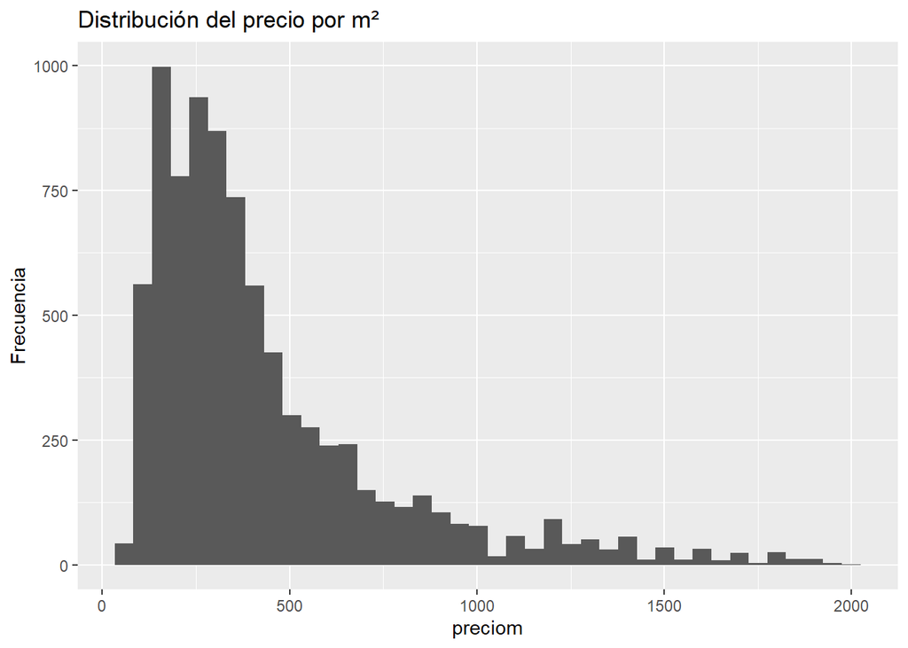

```r
ggplot(df, aes(x = preciom)) +
  geom_histogram(bins = 40) +
  labs(title = "Distribución del precio por m²", x = "preciom", y = "Frecuencia")
```

El precio por m² es asimétrico (cola a la derecha): hay pocos inmuebles muy caros. Esto sugiere segmentación del mercado.

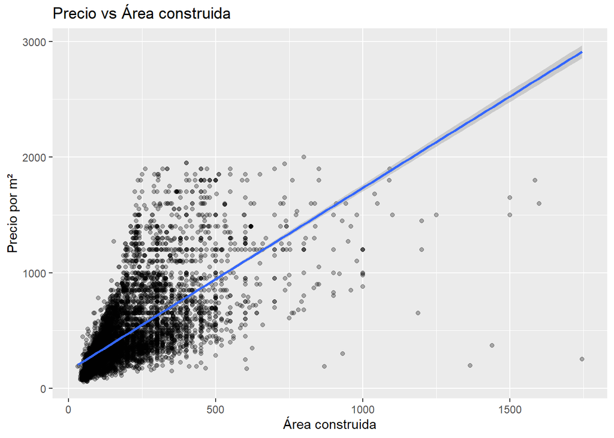

```r
ggplot(df, aes(x = areaconst, y = preciom)) +
  geom_point(alpha = 0.3) +
  geom_smooth(method = "lm") +
  labs(title = "Precio vs Área construida", x = "Área construida", y = "Precio por m²")
```

Se observa relación positiva general: a mayor área, tiende a cambiar el precio por m² (no siempre lineal; depende de zona/estrato).

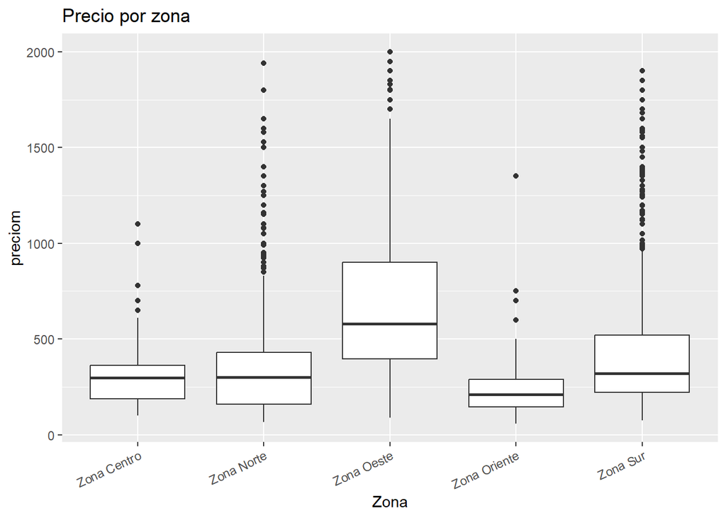

```r
ggplot(df, aes(x = zona, y = preciom)) +
  geom_boxplot() +
  theme(axis.text.x = element_text(angle = 25, hjust = 1)) +
  labs(title = "Precio por zona", x = "Zona", y = "preciom")
```

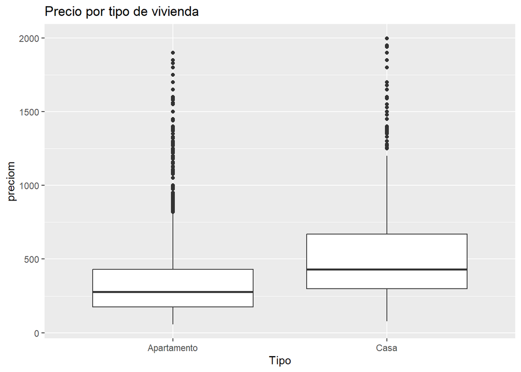

```r
ggplot(df, aes(x = tipo, y = preciom)) +
  geom_boxplot() +
  labs(title = "Precio por tipo de vivienda", x = "Tipo", y = "preciom")
```

Existen diferencias de precio por zona y tipo, lo que apoya usar técnicas multivariadas y segmentación

```r
df_imp <- df %>%
  mutate(parqueaderos = as.numeric(parqueaderos)) %>%
  select(-piso) # piso original no lo usamos; usamos piso_cat

# Configurar MICE
ini  <- mice(df_imp, maxit = 0)
meth <- ini$method
pred <- ini$predictorMatrix

# Método para parqueaderos
meth["parqueaderos"] <- "pmm"

# No usar id como predictor si existe
if ("id" %in% colnames(pred)) pred[, "id"] <- 0

set.seed(123)
imp <- mice(df_imp, method = meth, predictorMatrix = pred, m = 5, seed = 123)
df2 <- complete(imp, 1)
```

Como `parqueaderos` tiene ~19% de faltantes y es importante para valorar, se usa imputación múltiple (MICE) con **pmm** para conservar la distribución y evitar sesgos.

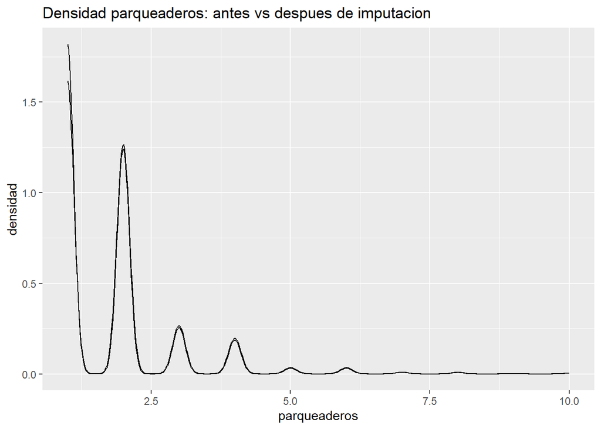

```r
ggplot() +
  geom_density(data = df,  aes(x = parqueaderos), na.rm = TRUE) +
  geom_density(data = df2, aes(x = parqueaderos), na.rm = TRUE) +
  labs(title = "Densidad parqueaderos: antes vs despues de imputacion",
       x = "parqueaderos", y = "densidad")
```

Continuaremos con el PCA

```r
# Variables numéricas que sí describen el inmueble (EXCLUIMOS id)
vars_num <- c("estrato","preciom","areaconst","parqueaderos","banios","habitaciones","longitud","latitud")

df_pca <- df2 %>% select(all_of(vars_num)) %>% drop_na()

# Estandarización para evitar sesgos por escalas distintas
Xz <- scale(df_pca)

# PCA
pca <- prcomp(Xz, center = TRUE, scale. = FALSE)
```

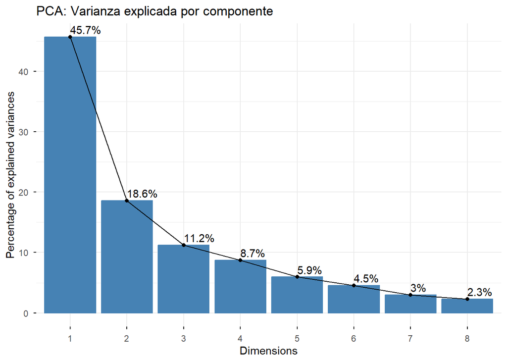

```r
fviz_eig(pca, addlabels = TRUE) +
  labs(title = "PCA: Varianza explicada por componente")
```

El primer componente principal (PC1) explica 45.7 de la variabilidad Los dos primeros componentes (PC1 + PC2) explican 64.3% acumulado Por lo tanto, el plano PC1–PC2 permite un resumen inicial del mercado, aunque puede requerirse PC3 para capturar más variación

```r
eig <- get_eigenvalue(pca)
eig
```

```
##       eigenvalue variance.percent cumulative.variance.percent
## Dim.1  3.6548756        45.685945                    45.68594
## Dim.2  1.4890094        18.612618                    64.29856
## Dim.3  0.8992776        11.240971                    75.53953
## Dim.4  0.6991753         8.739691                    84.27922
## Dim.5  0.4759328         5.949160                    90.22838
## Dim.6  0.3623483         4.529354                    94.75774
## Dim.7  0.2362330         2.952913                    97.71065
## Dim.8  0.1831480         2.289350                   100.00000
```

```r
round(pca$rotation[,1:2], 3)
```

```
##                 PC1    PC2
## estrato       0.327 -0.464
## preciom       0.464 -0.070
## areaconst     0.421  0.265
## parqueaderos  0.412  0.008
## banios        0.444  0.183
## habitaciones  0.260  0.547
## longitud     -0.231  0.464
## latitud      -0.115  0.402
```

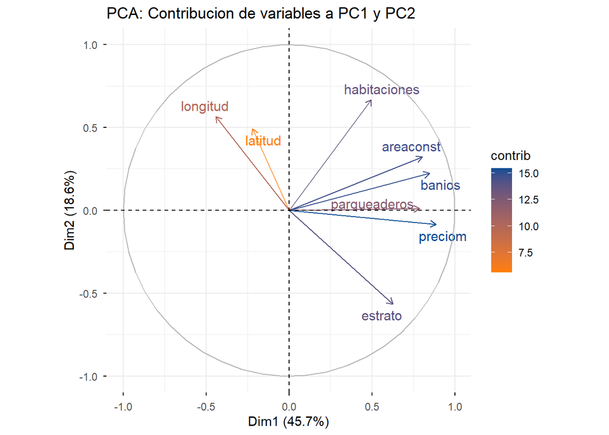

El primer componente principal (45.7% de la varianza) está asociado principalmente con las variables precio por m², número de baños, área construida, parqueaderos y estrato. Esto sugiere que PC1 captura un eje de valorización y nivel socioeconómico del inmueble.

El segundo componente principal (18.6%) está asociado principalmente con número de habitaciones y variables geográficas (latitud y longitud), representando un eje de diferenciación espacial y estructural.

En conjunto, PC1 y PC2 explican el 64.3% de la variabilidad del mercado, lo que permite una representación bidimensional adecuada para análisis exploratorio.

```r
df <- df %>%
  mutate(
    piso_cat = forcats::fct_explicit_na(as.factor(piso), na_level = "Sin dato")
  )
```

Se continuara con el analisis de cluster de la siguiente forma:

```r
# 1) Tomo parqueaderos imputado desde df2
parq_imp <- df2 %>% select(id, parqueaderos)

# 2) Reemplazo parqueaderos en df usando el imputado
df_clust_base <- df %>%
  select(id, zona, tipo, barrio, piso_cat, estrato, preciom, areaconst,
         banios, habitaciones, longitud, latitud, parqueaderos) %>%
  left_join(parq_imp, by = "id", suffix = c("_orig", "_imp")) %>%
  mutate(parqueaderos = parqueaderos_imp) %>%
  select(-parqueaderos_orig, -parqueaderos_imp)

# Variables numéricas para clustering
vars_num <- c("estrato","preciom","areaconst","parqueaderos",
              "banios","habitaciones","longitud","latitud")

df_clust <- df_clust_base %>% drop_na(all_of(vars_num))

# Estandarizar
Xc <- scale(df_clust %>% select(all_of(vars_num)))
```

Se usa `parqueaderos` imputado para no perder observaciones Se estandarizan variables para calcular distancias sin sesgo por escala

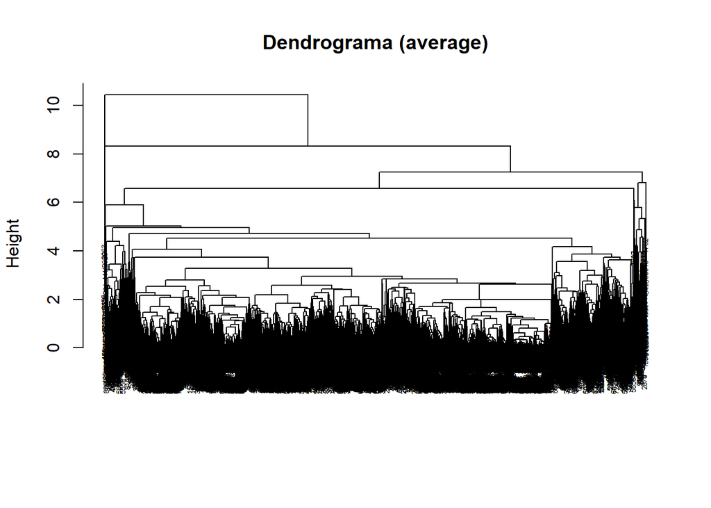

```r
dist_eucl <- dist(Xc, method = "euclidean")
hc <- hclust(dist_eucl, method = "average")

plot(hc, cex = 0.4, main = "Dendrograma (average)", xlab = "", sub = "")
```

Elegir k con Silhouette (k = 2 a 8)

```r
sil_means <- tibble(k = 2:8, sil = NA_real_)

for (i in 2:8) {
  grp <- cutree(hc, k = i)
  sil <- silhouette(grp, dist_eucl)
  sil_means$sil[sil_means$k == i] <- mean(sil[,3])
}

sil_means
```

```
## # A tibble: 7 × 2
##       k   sil
##   <int> <dbl>
## 1     2 0.647
## 2     3 0.556
## 3     4 0.492
## 4     5 0.479
## 5     6 0.440
## 6     7 0.439
## 7     8 0.423
```

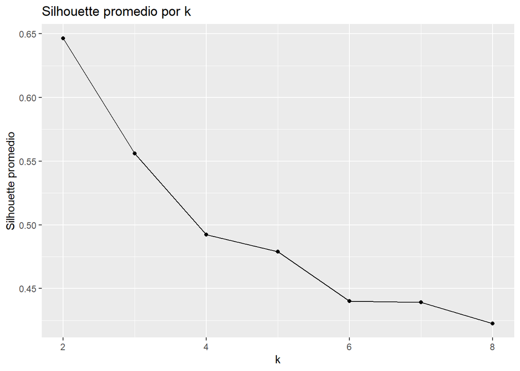

```r
ggplot(sil_means, aes(k, sil)) +
  geom_line() + geom_point() +
  labs(title = "Silhouette promedio por k", x = "k", y = "Silhouette promedio")
```

```r
k_final <- sil_means$k[which.max(sil_means$sil)]
k_final
```

```
## [1] 2
```

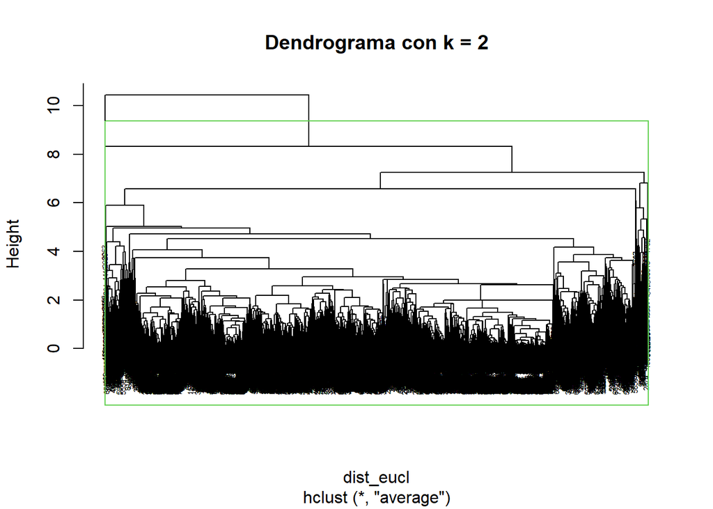

```r
df_clust <- df_clust %>%
  mutate(cluster = factor(cutree(hc, k = k_final)))

plot(hc, cex = 0.4, main = paste("Dendrograma con k =", k_final))
rect.hclust(hc, k = k_final, border = 2:(k_final+1))
```

```r
perfil <- df_clust %>%
  group_by(cluster) %>%
  summarise(
    n = n(),
    preciom_med = median(preciom),
    preciom_p25 = quantile(preciom, 0.25),
    preciom_p75 = quantile(preciom, 0.75),
    estrato_med = median(estrato),
    area_med = median(areaconst),
    banios_med = median(banios),
    parq_med = median(parqueaderos),
    hab_med = median(habitaciones),
    .groups = "drop"
  ) %>%
  arrange(desc(n))

perfil
```

```
## # A tibble: 2 × 10
##   cluster     n preciom_med preciom_p25 preciom_p75 estrato_med area_med
##   <fct>   <int>       <dbl>       <dbl>       <dbl>       <dbl>    <dbl>
## 1 1        8306         330        220         540            5      123
## 2 2           3         255        228.        312.           3     1440
## # ℹ 3 more variables: banios_med <dbl>, parq_med <dbl>, hab_med <dbl>
```

```r
# Solución alternativa para segmentación útil
k_alt <- 3
df_clust_k3 <- df_clust %>% mutate(cluster3 = factor(cutree(hc, k = k_alt)))

perfil3 <- df_clust_k3 %>%
  group_by(cluster3) %>%
  summarise(
    n = n(),
    preciom_med = median(preciom),
    preciom_p25 = quantile(preciom, 0.25),
    preciom_p75 = quantile(preciom, 0.75),
    estrato_med = median(estrato),
    area_med = median(areaconst),
    banios_med = median(banios),
    parq_med = median(parqueaderos),
    hab_med = median(habitaciones),
    .groups = "drop"
  ) %>%
  arrange(preciom_med)

perfil3
```

```
## # A tibble: 3 × 10
##   cluster3     n preciom_med preciom_p25 preciom_p75 estrato_med area_med
##   <fct>    <int>       <dbl>       <dbl>       <dbl>       <dbl>    <dbl>
## 1 2            3         255        228.        312.           3     1440
## 2 1         8302         330        220         540            5      123
## 3 3            4         370        310         530            4      210
## # ℹ 3 more variables: banios_med <dbl>, parq_med <dbl>, hab_med <dbl>
```

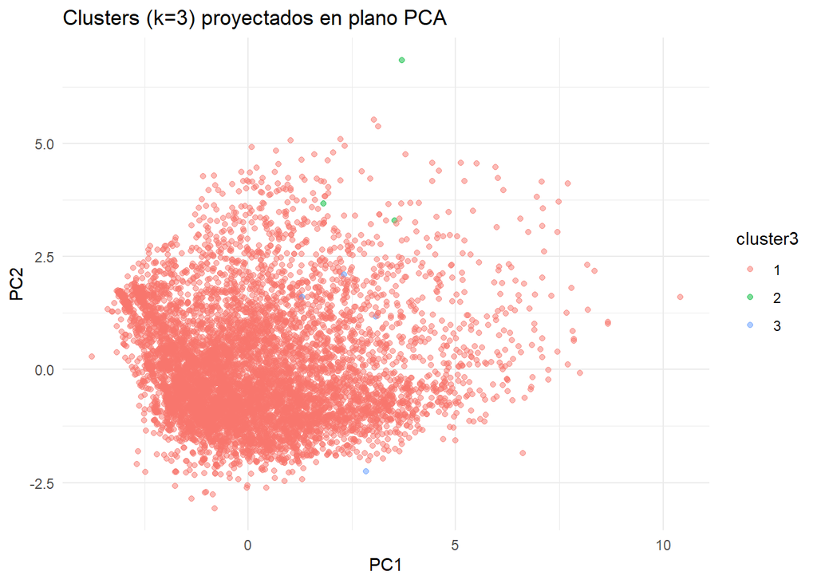

```r
# Obtener coordenadas PCA
df_pca_coords <- as.data.frame(pca$x[,1:2])

# Agregar cluster k=3
df_pca_coords$cluster3 <- df_clust_k3$cluster3

ggplot(df_pca_coords, aes(x = PC1, y = PC2, color = cluster3)) +
  geom_point(alpha = 0.5) +
  labs(title = "Clusters (k=3) proyectados en plano PCA",
       x = "PC1",
       y = "PC2") +
  theme_minimal()
```

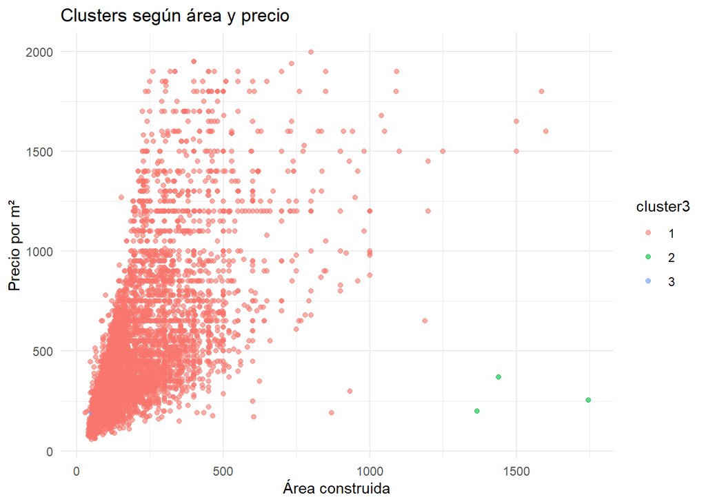

```r
ggplot(df_clust_k3, aes(x = areaconst, y = preciom, color = cluster3)) +
  geom_point(alpha = 0.6) +
  labs(title = "Clusters según área y precio",
       x = "Área construida",
       y = "Precio por m²") +
  theme_minimal()
```

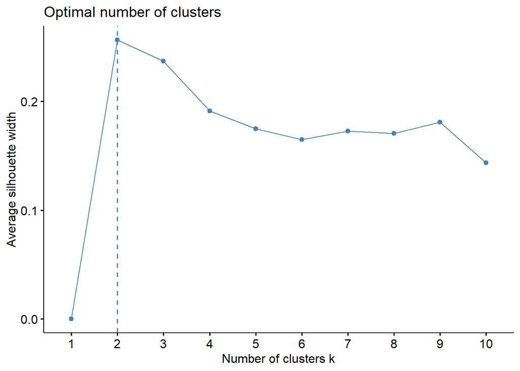

```r
# Quitar outliers extremos (ejemplo percentil 99)
df_filtrado <- df_clust %>%
  filter(preciom < quantile(preciom, 0.99))

Xf <- scale(df_filtrado %>% select(all_of(vars_num)))
hc_f <- hclust(dist(Xf), method = "average")

fviz_nbclust(Xf, FUN = hcut, method = "silhouette")
```

El analisis de acuerdo con las graficas planteadas es el siguiete

Lo que se puede ver con el algoritmo de cluster es que el mercado esta dominado homogeneamente y tiene variabilidad continua no hay segmentacion natural fuerte y el algoritmo esta clasificando fronteras por lo tanto el algoritmo identifica bien outliers

```r
tab_ze <- table(df$zona, df$estrato)
tab_ze
```

```
##
##                   3    4    5    6
##   Zona Centro   105   14    4    1
##   Zona Norte    572  407  768  172
##   Zona Oeste     52   82  287  768
##   Zona Oriente  340    8    2    1
##   Zona Sur      382 1616 1685 1043
```

```r
chi_ze <- chisq.test(tab_ze)
chi_ze
```

```
##
##  Pearson's Chi-squared test
##
## data:  tab_ze
## X-squared = 3839.5, df = 12, p-value < 2.2e-16
```

```r
ca_ze <- CA(tab_ze, graph = FALSE)

ca_ze$eig
```

```
##       eigenvalue percentage of variance cumulative percentage of variance
## dim 1 0.32311827              69.924825                          69.92483
## dim 2 0.12817234              27.737302                          97.66213
## dim 3 0.01080317               2.337873                         100.00000
```

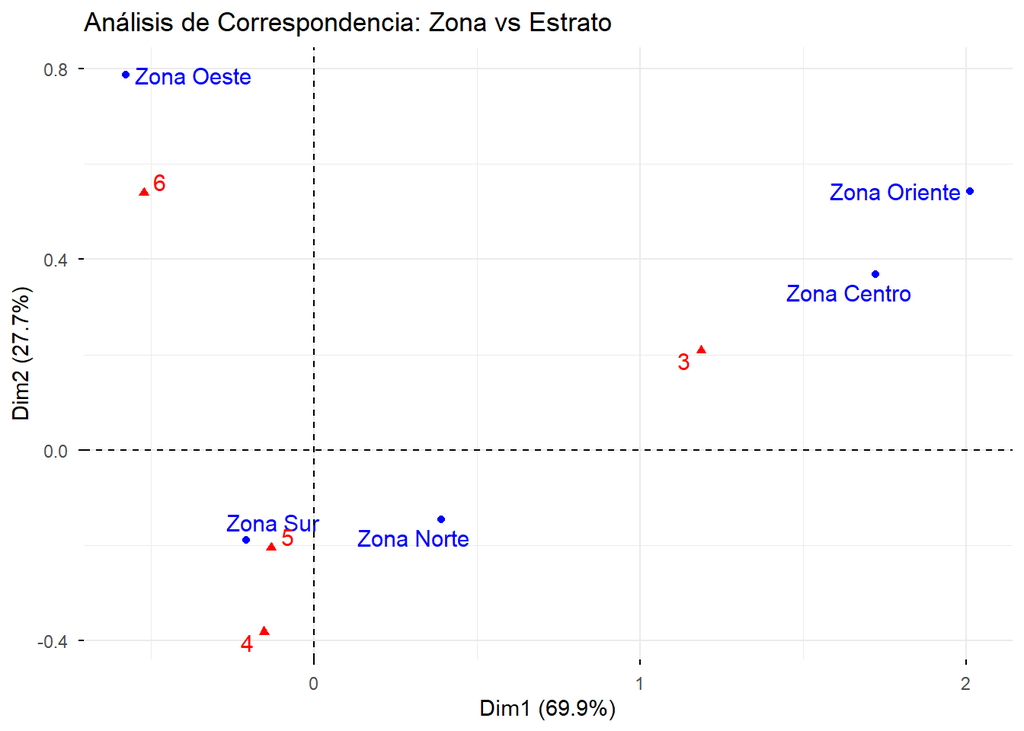

```r
fviz_ca_biplot(ca_ze, repel = TRUE) +
  labs(title = "Análisis de Correspondencia: Zona vs Estrato")
```

La prueba chi-cuadrado (χ² = 3839.5, p < 0.001) confirma una asociación altamente significativa entre la zona de la ciudad y el estrato socioeconómico.

El análisis de correspondencia generó tres dimensiones, donde las dos primeras explican el 97.7% de la inercia total (Dim1 = 69.9%, Dim2 = 27.7%), permitiendo una representación bidimensional prácticamente completa.

La Dimensión 1 representa un eje socioeconómico, diferenciando zonas asociadas a estratos bajos (3) de aquellas vinculadas a estratos altos (6).

En particular:

Zona Oeste se asocia fuertemente con estrato 6, caracterizándose como zona premium.

Zona Oriente y Zona Centro se relacionan principalmente con estrato 3, reflejando un perfil socioeconómico más popular.

Zona Norte y Zona Sur presentan asociación con estratos 4 y 5, representando segmentos intermedios del mercado.

Estos resultados evidencian una clara segmentación espacial del mercado inmobiliario según nivel socioeconómico, lo cual es fundamental para estrategias de pricing, inversión y desarrollo inmobiliario.

```r
# Top 10 barrios con más registros
top_barrios <- df %>%
  count(barrio, sort = TRUE) %>%
  slice_head(n = 10) %>%
  pull(barrio)

top_barrios
```

```
##  [1] valle del lili ciudad jardin  pance          la flora       santa teresita
##  [6] el caney       el ingenio     la hacienda    normandia      acopi
## 385 Levels: 20 de julio 3 de julio acopi agua blanca aguablanca ... zona sur
```

```r
tab_be <- df %>%
  filter(barrio %in% top_barrios) %>%
  count(barrio, estrato) %>%
  pivot_wider(names_from = estrato, values_from = n, values_fill = 0) %>%
  column_to_rownames("barrio")

tab_be
```

```
##                 3   4   5   6
## acopi          21  51  59  27
## ciudad jardin   2   4  67 467
## el caney        9 166  34   0
## el ingenio      0   9 157  37
## la flora        1  33 329   6
## la hacienda     2  29 134   1
## normandia       1   0  23 135
## pance           0   2  20 391
## santa teresita  0   4  27 232
## valle del lili  4 577 423   5
```

```r
chisq.test(tab_be)
```

```
##
##  Pearson's Chi-squared test
##
## data:  tab_be
## X-squared = 3734, df = 27, p-value < 2.2e-16
```

```r
ca_be <- CA(tab_be, graph = FALSE)

ca_be$eig
```

```
##       eigenvalue percentage of variance cumulative percentage of variance
## dim 1 0.77298332              72.226662                          72.22666
## dim 2 0.23319073              21.789070                          94.01573
## dim 3 0.06404475               5.984267                         100.00000
```

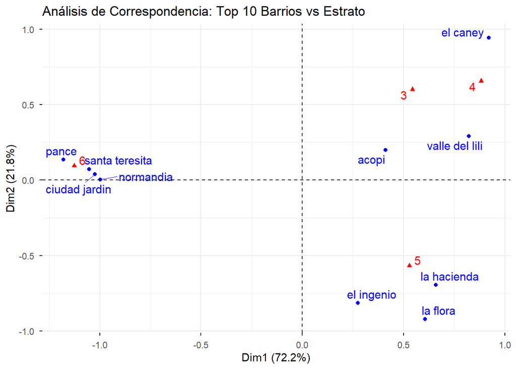

```r
fviz_ca_biplot(ca_be, repel = TRUE) +
  labs(title = "Análisis de Correspondencia: Top 10 Barrios vs Estrato")
```

El test Chi-cuadrado (X² = 3734, p < 0.001) indica que existe una asociación estadísticamente significativa entre barrio y estrato, rechazando la hipótesis de independencia. Esto confirma que la estructura socioeconómica del mercado inmobiliario presenta una clara diferenciación espacial.

El mapa revela que barrios como Pance, Santa Teresita y Ciudad Jardín se encuentran fuertemente asociados a estratos altos, mientras que barrios como Valle del Lili y El Caney presentan un perfil predominantemente medio. La Flora y El Ingenio muestran una asociación clara con estrato 5.

Estos resultados evidencian que el mercado inmobiliario urbano presenta patrones estructurales de concentración socioeconómica por barrio.

Desde una perspectiva aplicada:

La valoración debe considerar ubicación y estrato como variables estructurales.

El mercado no requiere segmentación excesiva; bastan grandes categorías.

Existen nichos premium claramente identificables.

La estructura socioeconómica territorial influye directamente en precios.